# Week 9 Lab - KEY

Prof. Amanda D. Perez, PhD

# Simple & Multiple Regression: Mario Kart Data

```r
library(tidyverse)
```

For this section you will be using Mario Kart Record data from TidyTuesday. See https://github.com/rfordatascience/tidytuesday/tree/master/data/2021/2021-05-25 for more detailed information about the dataset.

```r
mario <- read_csv("data/records.csv")

glimpse(mario)
```

```
## Rows: 2,334
## Columns: 9
## $ track           <chr> "Luigi Raceway", "Luigi Raceway", "Luigi Raceway", "Lu…
## $ type            <chr> "Three Lap", "Three Lap", "Three Lap", "Three Lap", "T…
## $ shortcut        <chr> "No", "No", "No", "No", "No", "No", "No", "No", "No", …
## $ player          <chr> "Salam", "Booth", "Salam", "Salam", "Gregg G", "Rocky …
## $ system_played   <chr> "NTSC", "NTSC", "NTSC", "NTSC", "NTSC", "NTSC", "NTSC"…
## $ date            <date> 1997-02-15, 1997-02-16, 1997-02-16, 1997-02-28, 1997-…
## $ time_period     <chr> "2M 12.99S", "2M 9.99S", "2M 8.99S", "2M 6.99S", "2M 4…
## $ time            <dbl> 132.99, 129.99, 128.99, 126.99, 124.51, 122.89, 122.87…
## $ record_duration <dbl> 1, 0, 12, 7, 54, 0, 0, 27, 0, 64, 3, 0, 90, 132, 1, 74…
```

## Exercise 1 -

```r
mario$track <- as.factor(mario$track)
levels(mario$track)
```

```
##  [1] "Banshee Boardwalk"     "Bowser's Castle"       "Choco Mountain"
##  [4] "D.K.'s Jungle Parkway" "Frappe Snowland"       "Kalimari Desert"
##  [7] "Koopa Troopa Beach"    "Luigi Raceway"         "Mario Raceway"
## [10] "Moo Moo Farm"          "Rainbow Road"          "Royal Raceway"
## [13] "Sherbet Land"          "Toad's Turnpike"       "Wario Stadium"
## [16] "Yoshi Valley"
```

Right now, `Banshee Boardwalk` is the default reference level. We know this because it is the first level that appears above. I want to change the reference level to `Bowser's Castle`. I will do that in the below code.

```r
mario$track <- relevel(mario$track, ref = "Bowser's Castle")
```

Below, I will confirm that `Bowser's Castle` is the new reference level.

```r
levels(mario$track)
```

```
##  [1] "Bowser's Castle"       "Banshee Boardwalk"     "Choco Mountain"
##  [4] "D.K.'s Jungle Parkway" "Frappe Snowland"       "Kalimari Desert"
##  [7] "Koopa Troopa Beach"    "Luigi Raceway"         "Mario Raceway"
## [10] "Moo Moo Farm"          "Rainbow Road"          "Royal Raceway"
## [13] "Sherbet Land"          "Toad's Turnpike"       "Wario Stadium"
## [16] "Yoshi Valley"
```

`Bowser's Castle` shows up first and is now our reference level. We can now move on to our simple regression. Fill in the formula below to run a regression predicting `time` (the DV) from `track` (the IV). When you have correctly specified the `lm()` model, the `summary(mod.mario.simple)` will run without error.

```r
mod.mario.simple <- lm(time ~ track, data = mario)
summary(mod.mario.simple)
```

```
##
## Call:
## lm(formula = time ~ track, data = mario)
##
## Residuals:
##     Min      1Q  Median      3Q     Max
## -154.89  -38.70  -22.50   39.64  170.56
##
## Coefficients:
##                            Estimate Std. Error t value Pr(>|t|)
## (Intercept)                  96.228      6.466  14.882  < 2e-16 ***
## trackBanshee Boardwalk        1.212      8.751   0.139 0.889809
## trackChoco Mountain         -25.442      7.830  -3.249 0.001173 **
## trackD.K.'s Jungle Parkway  -25.243      7.605  -3.319 0.000917 ***
## trackFrappe Snowland        -37.638      7.605  -4.949 8.00e-07 ***
## trackKalimari Desert        -19.317      7.674  -2.517 0.011893 *
## trackKoopa Troopa Beach     -23.813      8.616  -2.764 0.005756 **
## trackLuigi Raceway          -21.907      7.838  -2.795 0.005234 **
## trackMario Raceway          -42.032      7.736  -5.433 6.11e-08 ***
## trackMoo Moo Farm           -35.159      8.799  -3.996 6.65e-05 ***
## trackRainbow Road           109.045      7.611  14.327  < 2e-16 ***
## trackRoyal Raceway           12.980      7.821   1.659 0.097153 .
## trackSherbet Land           -18.084      7.873  -2.297 0.021711 *
## trackToad's Turnpike          2.651      7.519   0.353 0.724458
## trackWario Stadium           35.807      7.494   4.778 1.88e-06 ***
## trackYoshi Valley           -40.648      7.736  -5.254 1.62e-07 ***
## ---
## Signif. codes:  0 '***' 0.001 '**' 0.01 '*' 0.05 '.' 0.1 ' ' 1
##
## Residual standard error: 53.71 on 2318 degrees of freedom
## Multiple R-squared:  0.3551, Adjusted R-squared:  0.351
## F-statistic:  85.1 on 15 and 2318 DF,  p-value: < 2.2e-16
```

Your job is to interpret:

## Exercise 2 -

Next we will visualize the regression model. I have provided a basic graph for your below. Your job is to update the graph and: fill each bar by track, add a theme, hide the legend using `guides` argument, label the x and y axes, and add a title. Interpret what you see.

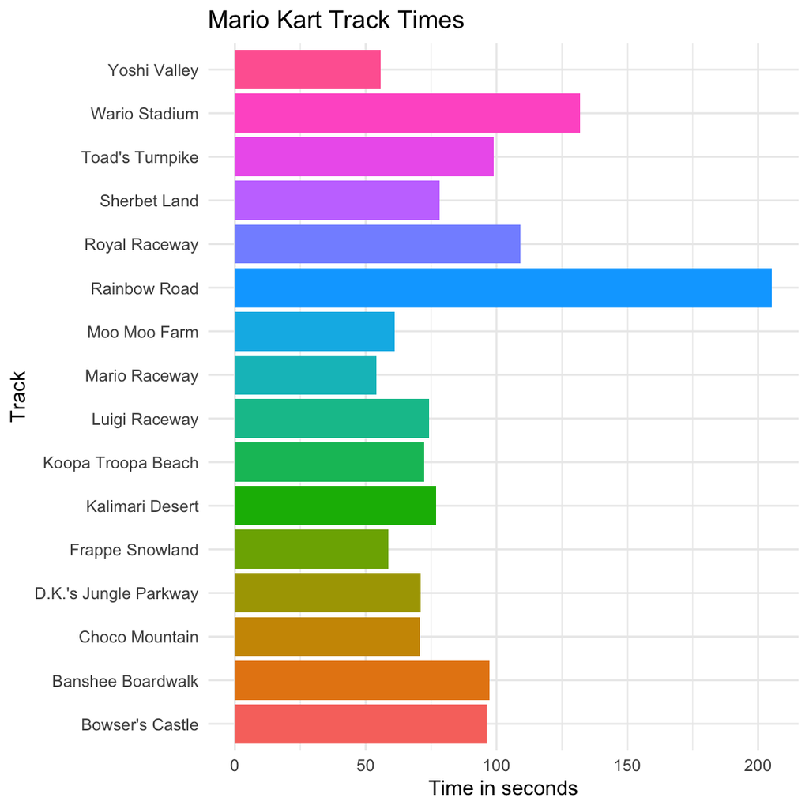

```r
ggplot(mario, aes(track, time, fill = track)) +
  stat_summary(fun = "mean", geom = "bar") +
  coord_flip() +
  labs(x = "Track", y = "Time in seconds", title = "Mario Kart Track Times") +
  guides(fill = "none") +
  theme_minimal()
```

## Exercise 3 -

Now that we have run a simple regression (regression with just one IV) we want to now run a multiple regression. We want to run a new model that will add on a second IV: `type`

```r
mario$type <- as.factor(mario$type)
levels(mario$type)
```

```
## [1] "Single Lap" "Three Lap"
```

In this case, the reference level is `Single Lap`. I like this and will not change the reference level.

Now, it is time to build our multiple regression model. We will be predicting `time` (DV) from `track` (IV 1) AND `type` (IV 2). When you have correctly specified the `lm()` model, the `summary(mod.mario.multiple)` will run without error.

```r
mod.mario.multiple <- lm(time ~ track + type, data = mario)
summary(mod.mario.multiple)
```

```
##
## Call:
## lm(formula = time ~ track + type, data = mario)
##
## Residuals:
##      Min       1Q   Median       3Q      Max
## -189.612  -11.082    4.241   12.608  135.838
##
## Coefficients:
##                            Estimate Std. Error t value Pr(>|t|)
## (Intercept)                  51.194      4.604  11.120  < 2e-16 ***
## trackBanshee Boardwalk       -5.231      6.108  -0.856 0.391919
## trackChoco Mountain         -24.499      5.464  -4.483 7.71e-06 ***
## trackD.K.'s Jungle Parkway  -17.324      5.310  -3.263 0.001120 **
## trackFrappe Snowland        -32.309      5.309  -6.086 1.35e-09 ***
## trackKalimari Desert         -7.839      5.360  -1.462 0.143789
## trackKoopa Troopa Beach     -27.659      6.013  -4.600 4.46e-06 ***
## trackLuigi Raceway          -19.679      5.470  -3.597 0.000328 ***
## trackMario Raceway          -36.811      5.400  -6.817 1.18e-11 ***
## trackMoo Moo Farm           -32.324      6.141  -5.263 1.55e-07 ***
## trackRainbow Road           111.115      5.312  20.918  < 2e-16 ***
## trackRoyal Raceway           17.868      5.459   3.273 0.001080 **
## trackSherbet Land           -12.707      5.496  -2.312 0.020855 *
## trackToad's Turnpike         -1.462      5.248  -0.279 0.780588
## trackWario Stadium           53.401      5.242  10.186  < 2e-16 ***
## trackYoshi Valley           -31.542      5.402  -5.839 5.99e-09 ***
## typeThree Lap                77.683      1.572  49.419  < 2e-16 ***
## ---
## Signif. codes:  0 '***' 0.001 '**' 0.01 '*' 0.05 '.' 0.1 ' ' 1
##
## Residual standard error: 37.49 on 2317 degrees of freedom
## Multiple R-squared:  0.6861, Adjusted R-squared:  0.6839
## F-statistic: 316.5 on 16 and 2317 DF,  p-value: < 2.2e-16
```

Your job is to interpret:

## Exercise 4 -

Next we will visualize the multiple regression model. I have provided a basic graph for your below. Your job is to update the graph and: fill each bar by type, add a theme, and label the x and y axes, label the fill title (legend), and add a title. Interpret what you see.

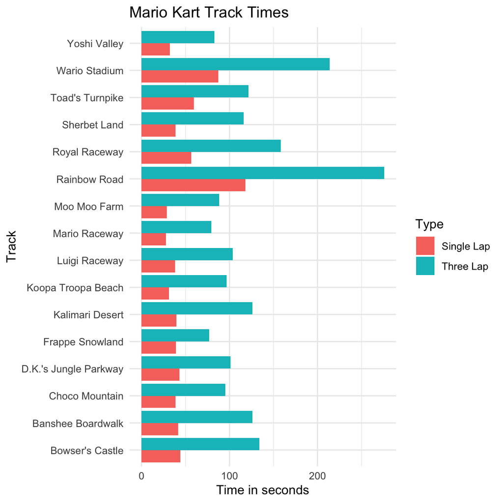

```r
ggplot(mario, aes(track, time, fill = type) )+
  stat_summary(fun = "mean", geom = "bar", position = "dodge") +
  coord_flip() +
  labs(x = "Track", y = "Time in seconds", fill = "Type", title = "Mario Kart Track Times")  +
  theme_minimal()
```

# Simple & Multiple Regression: Fishing Data

```r
library(tidyverse)
```

For this section you will be using Great Lakes Fishery Commission data from TidyTuesday. See https://github.com/rfordatascience/tidytuesday/tree/master/data/2021/2021-06-08 for more detailed information about the dataset.

```r
set.seed(5678)
fishing <- read_csv("data/fishing.csv") %>%
  sample_n(8000)

glimpse(fishing)
```

```
## Rows: 8,000
## Columns: 7
## $ year        <dbl> 1962, 1905, 1932, 1984, 1956, 2007, 1924, 1867, 2005, 2004…
## $ lake        <chr> "Erie", "Huron", "Saint Clair", "Erie", "Ontario", "Erie",…
## $ species     <chr> "Lake Sturgeon", "Chubs", "Carp", "White Perch", "Amercian…
## $ grand_total <dbl> 2, NA, NA, 912, 60, 451, NA, NA, NA, 2, 1952, NA, NA, 50, …
## $ comments    <chr> NA, NA, NA, NA, NA, NA, NA, NA, NA, NA, NA, NA, "WI Totals…
## $ region      <chr> "New York (NY)", "U.S. Total (MI)", "U.S. Total (MI)", "Mi…
## $ values      <dbl> 0, 1163, NA, 0, 10, 342, NA, NA, 0, NA, 866, NA, 26833, 24…
```

## Exercise 5 -

We will be running a simple regression to predict `grand_total` from `species`. As you can see below, there are `51` different species. Unlike the previous simple regression, I am only interested in 5 different fish species: Buffalo, Crappie, Herring, White Bass, and Yellow Perch.

```r
fishing$species <- as.factor(fishing$species)
levels(fishing$species)
```

```
##  [1] "Alewife"                       "Amercian Eel"
##  [3] "American Eel"                  "Blue Pike"
##  [5] "Bowfin"                        "Buffalo"
##  [7] "Bullhead"                      "Bullheads"
##  [9] "Burbot"                        "Carp"
## [11] "Channel catfish"               "Channel Catfish"
## [13] "Channel Catfish and Bullheads" "Chinook Salmon"
## [15] "Chubs"                         "Cisco"
## [17] "Cisco and Chub"                "Cisco and chubs"
## [19] "Cisco and Chubs"               "Coho Salmon"
## [21] "Crappie"                       "Crappies"
## [23] "Drum"                          "Freshwater Drum"
## [25] "Gizzard Shad"                  "Goldfish"
## [27] "Herring"                       "Lake Sturgeon"
## [29] "Lake Trout"                    "Lake Trout - siscowet"
## [31] "Lake Whitefish"                "Minnows"
## [33] "Northern Pike"                 "Pacific salmon"
## [35] "Pacific Salmon"                "Quillback"
## [37] "Rainbow Smelt"                 "Rock Bass"
## [39] "Rock Bass and Crappie"         "Round Whitefish"
## [41] "Sauger"                        "Sheepshead"
## [43] "Smallmouth Bass"               "Suckers"
## [45] "Sunfish"                       "Walleye"
## [47] "Walleye and Blue Pike"         "White bass"
## [49] "White Bass"                    "White Perch"
## [51] "Yellow Perch"
```

Below I am filtering the data to only include these levels:

```r
fishing <- fishing %>%
  filter(species == "Buffalo" | species == "Crappie" | species == "Herring" | species == "White Bass" | species == "Yellow Perch")

fishing$species <- droplevels(fishing$species)
levels(fishing$species)
```

```
## [1] "Buffalo"      "Crappie"      "Herring"      "White Bass"   "Yellow Perch"
```

Above we see that `Buffalo` is the reference level. However, I want `White Bass` to be the reference level:

```r
fishing$species <- relevel(fishing$species, ref = "White Bass")
```

Below, I will confirm that `White Bass` is the new reference level.

```r
levels(fishing$species)
```

```
## [1] "White Bass"   "Buffalo"      "Crappie"      "Herring"      "Yellow Perch"
```

`White Bass` shows up first and is now our reference level. We can now move on to our simple regression. Fill in the formula below to run a regression predicting `grand_total` (the DV) from `species` (the IV). When you have correctly specified the `lm()` model, the `summary(mod.fish.simple)` will run without error.

```r
mod.fish.simple <- lm(grand_total ~ species, data = fishing)
summary(mod.fish.simple)
```

```
##
## Call:
## lm(formula = grand_total ~ species, data = fishing)
##
## Residuals:
##     Min      1Q  Median      3Q     Max
## -3307.1 -2620.1  -886.1   233.9 29858.9
##
## Coefficients:
##                     Estimate Std. Error t value Pr(>|t|)
## (Intercept)           1905.0      456.6   4.172 3.64e-05 ***
## speciesBuffalo       -1784.9      726.4  -2.457  0.01439 *
## speciesCrappie       -1893.3     1047.3  -1.808  0.07132 .
## speciesHerring       -1672.3     1768.4  -0.946  0.34486
## speciesYellow Perch   1402.1      538.1   2.606  0.00948 **
## ---
## Signif. codes:  0 '***' 0.001 '**' 0.01 '*' 0.05 '.' 0.1 ' ' 1
##
## Residual standard error: 4520 on 439 degrees of freedom
##   (271 observations deleted due to missingness)
## Multiple R-squared:  0.07481,    Adjusted R-squared:  0.06638
## F-statistic: 8.874 on 4 and 439 DF,  p-value: 6.747e-07
```

Your job is to interpret:

## Exercise 6 -

Next we will visualize the regression model. This time, you must write your own ggplot code. Make sure you: fill each bar by species, add a theme, hide the legend using `guides` argument, label the x and y axes, and add a title. Interpret what you see.

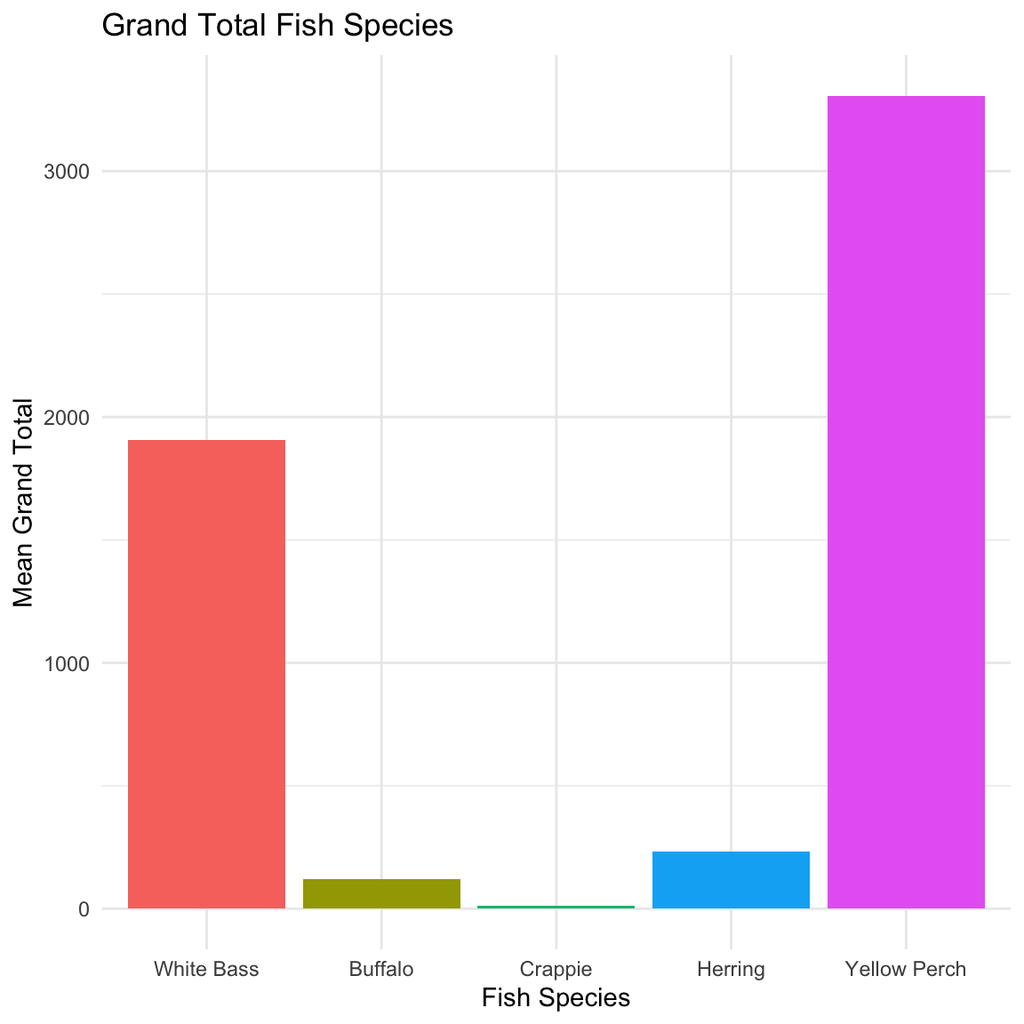

```r
ggplot(fishing, aes(species, grand_total, fill = species)) +
  stat_summary(fun = "mean", geom = "bar")  +
  labs(x = "Fish Species", y = "Mean Grand Total", title = "Grand Total Fish Species") +
  guides(fill = "none") +
  theme_minimal()
```

## Exercise 7 -

Now that we have run a simple regression (regression with just one IV) we want to now run a multiple regression. We want to run a new model that will add on a second IV: `lake`

```r
fishing$lake <- as.factor(fishing$lake)
levels(fishing$lake)
```

```
## [1] "Erie"        "Huron"       "Michigan"    "Ontario"     "Saint Clair"
## [6] "Superior"
```

In this case, the reference level is `Erie`. I like this and will not change the reference level.

Now, it is time to build our multiple regression model. We will be predicting `grand_total` (DV) from `species` (IV 1) AND `lake` (IV 2). When you have correctly specified the `lm()` model, the `summary(mod.fish.multiple)` will run without error. This is running an INTERACTION Model. You can ignore the rows with `NA`s. The NA rows mean there are not data points for that specific combination of data points.

```r
mod.fish.multiple <- lm(grand_total ~ species * lake, data = fishing)
summary(mod.fish.multiple)
```

```
##
## Call:
## lm(formula = grand_total ~ species * lake, data = fishing)
##
## Residuals:
##     Min      1Q  Median      3Q     Max
## -8497.4  -318.6    -8.1    51.0 23376.6
##
## Coefficients: (10 not defined because of singularities)
##                                     Estimate Std. Error t value Pr(>|t|)
## (Intercept)                           3723.3      450.9   8.258 1.86e-15 ***
## speciesBuffalo                       -3504.1      708.7  -4.944 1.10e-06 ***
## speciesCrappie                       -3719.1     1656.7  -2.245  0.02529 *
## speciesHerring                         232.4     1606.8   0.145  0.88507
## speciesYellow Perch                   6066.1      586.9  10.335  < 2e-16 ***
## lakeHuron                            -3709.2      708.7  -5.234 2.61e-07 ***
## lakeOntario                          -3715.7     1495.5  -2.485  0.01335 *
## lakeSaint Clair                      -3723.0     1154.5  -3.225  0.00136 **
## lakeSuperior                         -9751.3      904.9 -10.776  < 2e-16 ***
## speciesBuffalo:lakeHuron              3497.9     1073.2   3.259  0.00121 **
## speciesCrappie:lakeHuron                  NA         NA      NA       NA
## speciesHerring:lakeHuron                  NA         NA      NA       NA
## speciesYellow Perch:lakeHuron        -5034.5      856.4  -5.879 8.33e-09 ***
## speciesBuffalo:lakeOntario                NA         NA      NA       NA
## speciesCrappie:lakeOntario            3724.7     2305.0   1.616  0.10684
## speciesHerring:lakeOntario                NA         NA      NA       NA
## speciesYellow Perch:lakeOntario      -5752.4     1663.9  -3.457  0.00060 ***
## speciesBuffalo:lakeSaint Clair        3503.8     3434.7   1.020  0.30825
## speciesCrappie:lakeSaint Clair            NA         NA      NA       NA
## speciesHerring:lakeSaint Clair            NA         NA      NA       NA
## speciesYellow Perch:lakeSaint Clair  -6010.0     1365.6  -4.401 1.36e-05 ***
## speciesBuffalo:lakeSuperior               NA         NA      NA       NA
## speciesCrappie:lakeSuperior               NA         NA      NA       NA
## speciesHerring:lakeSuperior               NA         NA      NA       NA
## speciesYellow Perch:lakeSuperior          NA         NA      NA       NA
## ---
## Signif. codes:  0 '***' 0.001 '**' 0.01 '*' 0.05 '.' 0.1 ' ' 1
##
## Residual standard error: 3188 on 429 degrees of freedom
##   (271 observations deleted due to missingness)
## Multiple R-squared:  0.5502, Adjusted R-squared:  0.5355
## F-statistic: 37.48 on 14 and 429 DF,  p-value: < 2.2e-16
```

Your job is to interpret:

**How many significant interactions are there?**

## Exercise 8 -

Next we will visualize the multiple regression model. This time, you must write your own ggplot code. Make sure you: make species the x axis, fill each bar by lake, add a theme, label the x and y axes, label the fill title (legend), and add a title. Interpret what you see.

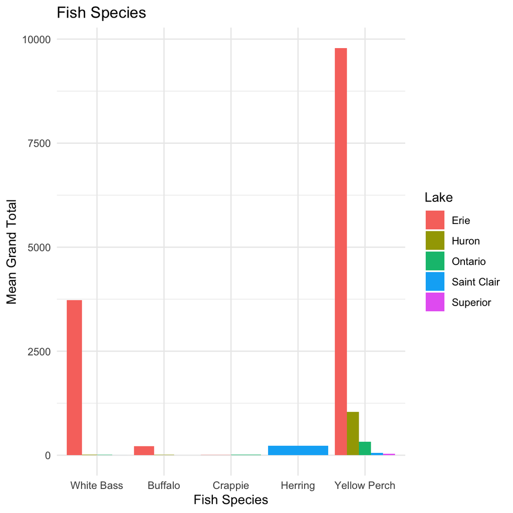

```r
ggplot(fishing, aes(species, grand_total, fill = lake) )+
  stat_summary(fun = "mean", geom = "bar", position = "dodge") +
  labs(x = "Fish Species", y = "Mean Grand Total", fill = "Lake", title = "Fish Species")  +
  theme_minimal()
```